# Preprocessing with Python

## Introduction

*Author: Kyriacos Nicolaou (kyriakosn24@gmail.com)*  
*Updated: October 9, 2024*

In this notebook, we will preprocess images from a multiplex immunofluoresence experiment to obtain the necessary components do spatial modeling of puncta patterns. The preprocessing steps include:

1. **Extracting Puncta Centroids**: From the images representing the puncta structures, we aim to pinpoint their centroid coordinates to generate a list of points.
2. **Defining the cell interior**: We need to obtain the contour of the domain where the puncta are located. This domain corresponds to the cytosol—the interior region of the cell excluding the nucleus.
3. **Constructing Derived Predictor Maps**: We will create derived predictor maps such as binary masks, distance maps, and proximity maps based on the imaged components.
4. **Stitching data for Multiple Cells**: To fit the model on multiple cells, we will geographically "stitch" the different images and point patterns into a single composite dataset.
5. **Export data** : We will export the contents of these dictionaries in an appropriate format for spatial modeling in R.

The final output will be a dictionary with the following structure:

```
dataset
├── cell1
│   ├── raw
│   |   ├── peroxisomes
│   |   ├── nucleus
│   |   ├── lipid droplets
│   |   ├── mitochondria
│   |   ├── golgi
│   |   └── ER
|   ├── point patterns
│   |   ├── peroxisomes
│   |   └── lipid droplets
│   ├── contours
|   |   ├── nucleus
|   |   └── cell border
|   ├── binary
|   |   ├── mitochondria
|   |   └── ER
|   ├── proximity
|   |   ├── mitochondria
|   └── distance fraction
|       └── nucleus_boarder
├── cell2
│   ├── raw
│   |   ├── peroxisomes
|   |   ...
|   ...
...
├── stitched_dataset
    ├── raw
    |   ├── peroxisomes
    |   ├── nucleus
    |   ├── lipid droplets
    |   ├── mitochondria
    |   ├── golgi
    |   └── ER
    ├── point patterns
    │   ├── peroxisomes
    │   └── lipid droplets
    ├── contours
    |   ├── nucleus
    |   └── cell border
    ├── binary
    |   ├── mitochondria
    |   └── ER
    ├── proximity
    |   ├── mitochondria
    └── distance fraction
       └── nucleus_boarder
```

## Importing Libraries

We will import the necessary libraries for preprocessing:

- **[Pillow](https://python-pillow.org/)**: For reading the raw images
- **[Geopandas](https://geopandas.org/en/stable/)**, **[rasterio](https://rasterio.readthedocs.io/en/stable/index.html)**, **[Shapely](https://shapely.readthedocs.io/en/2.0.3/index.html)**: For data export to approriate formats for R-inlabru analysis.
- **[NumPy](https://numpy.org/)**, **[SciPy](https://scipy.org/)**: For numerical computations and handling arrays.
- **[OpenCV](https://opencv.org/)**, **[scikit-image](https://scikit-image.org/)**: For image processing.
- **[Matplotlib](https://matplotlib.org/)**: For data visualization.

Let's import these lbraries below.

```python
import PIL
import geopandas as gpd
import shapely
import rasterio
import numpy as np
import scipy as sp
import cv2 as cv2
import skimage as sk
import matplotlib.pyplot as plt
import itertools
```

## Reading Raw Images for Each Cell

We will collect raw image data for each cell into a dictionary. Each image has multiple channels, each representing a different cellular component:

| Index | Channel |
| --- | --- |
| 0 | Nucleus |
| 1 | Lipid Droplets |
| 2 | Peroxisomes |
| 3 | Mitochondria |
| 4 | Golgi Apparatus |
| 5 | Endoplasmic Reticulum (ER) |
| 6 | Nucleus |

**Note:** there are two nucleus channels since they were used for alignment in the multiplex experiment, in our case we will neglet the channel at index 6

These raw images will be stored in our dataset dictionary

```python
# List of cells to process
cell_list = ["cell1", "cell2", "cell3", "cell4", "cell5", "cell6"]

scale = 10.8557

# Initialize the dataset dictionary
dataset = {cell: {} for cell in cell_list}

for cell in cell_list:
    dataset[cell]["raw"] = dict()
    dataset[cell]["binary"] = dict()
    dataset[cell]["point patterns"] = dict()
    dataset[cell]["contours"] = dict()
    dataset[cell]["proximity"] = dict()
    dataset[cell]["distance"] = dict()

dataset["scale"] = 10.8557  # pixels per micrometer

# List of all channels in the images
all_channels = ["nucleus", "lipid droplets", "peroxisomes", "mitochondria", "golgi", "ER"]

# Read all images for each cell
for cell in cell_list:
    file_path = f"../data/raw/{cell}/mpx.tif"
    with PIL.Image.open(file_path) as img:
        # Iterate over each frame (channel) in the TIFF file
        for frame, channel in enumerate(all_channels):
            try:
                img.seek(frame)
                dataset[cell]["raw"][channel] = np.array(img)
            except EOFError:
                print(f"Frame {frame} not found in {file_path}")
                break
```

## Visualization Helper Functions

To facilitate data exploration and visualization, we will construct two helper functions:

- **`imshow(axis,image)`**: this function plots an image in grayscale with black indicating high intensity and white indicating low intensity, the image is shown such that the origin is at the lower left corner, and the axis are adusted for the corresponding lengths, more over a scale bar of $10 \mathrm{\mu} m$ is added
- **`multiplot(dataset_dictionary,cells, imagesets, imagesubsets)`**: This function takes a dictionary in the format we showed before, meaning the first layer is the cell names, second layer are different image sets (e.g. raw,binary,distance) and last image subsets (e.g mitochondria, er), and lists for each layer cells, sets, subsets. The function will plot a multipannel figure with the images that correspond to the combinations of the elements of these lists.

```python
def imshow(ax,image):
    xlength = image.shape[1]/scale
    ylength = image.shape[0]/scale
    ax.imshow(image, cmap='binary',origin = "lower",extent = (0,xlength,0,ylength))
    ax.plot([xlength-15,xlength-5],[0.05*ylength,0.05*ylength],color = "black")
    ax.text(s = r"$10\mathrm{\mu m}$",x = xlength-10, y = 0.07*ylength,horizontalalignment = "center")
    ax.set_xticks([])
    ax.set_yticks([])


def multiplot(dataset_dictionary, cells, imagesets, imagesubsets):

    combinations = list(itertools.product(cells, imagesets, imagesubsets))
    number_of_images = len(combinations)

    ncols = 3
    nrows = int(np.ceil(number_of_images / ncols))

    # Create subplots
    fig, axes = plt.subplots(nrows=nrows, ncols=ncols, figsize=(5, 5))
    axes = axes.flatten()

    # Plot each image
    for idx, keys in enumerate(combinations):
        cell,set,subset = keys
        ax = axes[idx]
        image = dataset_dictionary[cell][set][subset]
        imshow(ax,image)
        ax.set_title(f"{cell}/{set}/{subset}",fontsize = 8)
    # Hide any unused subplots
    for idx in range(number_of_images, nrows * ncols):
        fig.delaxes(axes[idx])
    plt.tight_layout()
    plt.show()
```

lets test the visualization functions, by ploting all the raw images for cell1

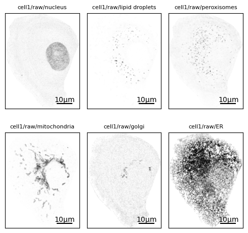

```python
multiplot(dataset,["cell1"], ["raw"], all_channels)
```

and now lets try to plot for cells: cell1, cell2, cell3, the raw images of their ER and mitochondria

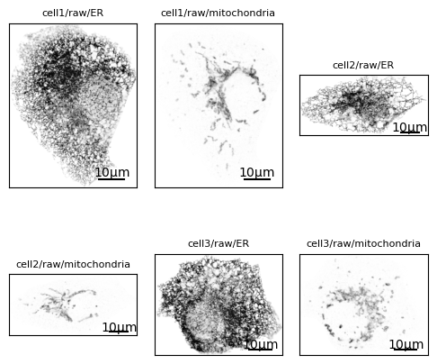

```python
multiplot(dataset,["cell1","cell2","cell3"], ["raw"],["ER","mitochondria"])
```

## Localizing Puncta Structures

We will **localize puncta structures** within the cells. Puncta are small, dot-like features representing cellular components like peroxisomes or lipid droplets. Accurate localization allows us to quantify puncta distribution and analyze spatial patterns.

```python
# function to get puncta coordinates and radius
def get_blobs(image,min_sigma,max_sigma,threshold,ns):
    blobs_log = sk.feature.blob_log(image,min_sigma=min_sigma, max_sigma=max_sigma, num_sigma=ns, threshold = threshold)
    return blobs_log[:,1]/scale ,blobs_log[:,0]/scale , np.sqrt(2)*blobs_log[:,2]/scale

max_size_in_px = 10 #about 1 um
min_size_in_px = 1 #about 0.1 um
n_steps = 10
threshold_peroxisomes = 60
threshold_lipid = 200


for cell in cell_list:
    peroxisomes_x, peroxisomes_y, peroxisomes_r = get_blobs(dataset[cell]["raw"]["peroxisomes"]*1.0,min_size_in_px,max_size_in_px,threshold_peroxisomes, n_steps)
    dataset[cell]["point patterns"]["peroxisomes"] = np.array([peroxisomes_x, peroxisomes_y, peroxisomes_r])

    lipid_x, lipid_y, lipid_r = get_blobs(dataset[cell]["raw"]["lipid droplets"]*1.0,min_size_in_px,max_size_in_px,threshold_lipid, n_steps)
    dataset[cell]["point patterns"]["lipid droplets"] = np.array([ lipid_x, lipid_y, lipid_r])
```

lets check how well the method captures the peroxisome and lipid droplets locations

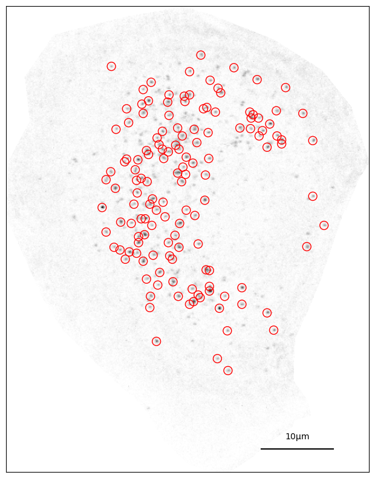

```python
fig, ax = plt.subplots(nrows=1, ncols=1, figsize=(10 ,10))
test_cell = "cell1"
imshow(ax,dataset[test_cell]["raw"]["peroxisomes"])
ax.scatter(dataset[test_cell]["point patterns"]["peroxisomes"][0],dataset[test_cell]["point patterns"]["peroxisomes"][1],s = 100, facecolors='none', edgecolors='r')
```

```python
for cell in cell_list:
    print(dataset[cell]["point patterns"]["peroxisomes"].shape)
```

```
(3, 138)
(3, 73)
(3, 100)
(3, 39)
(3, 46)
(3, 37)
```

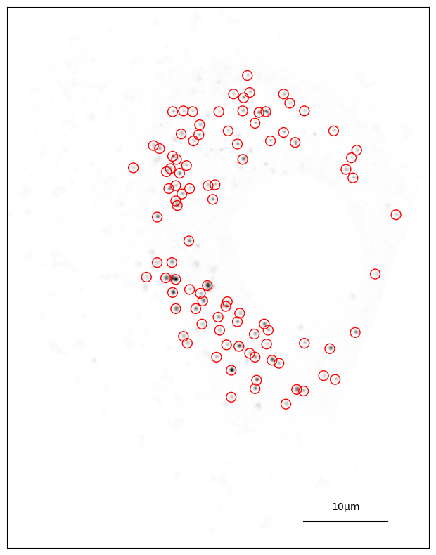

```python
fig, ax = plt.subplots(nrows=1, ncols=1, figsize=(10 ,10))
test_cell = "cell1"
imshow(ax,dataset[test_cell]["raw"]["lipid droplets"])
ax.scatter(dataset[test_cell]["point patterns"]["lipid droplets"][0],dataset[test_cell]["point patterns"]["lipid droplets"][1],s = 100, facecolors='none', edgecolors='r')
```

## Identifying Cell Domain and Extracting Contours

We will identify the cell domain and extract the contours of the cell boundary and nucleus to define spatial regions for analysis:

1. **Create Binary Masks**: Generate binary masks for the cell and nucleus using thresholding techniques.
2. **Extract Contours**: Use OpenCV's contour detection functions to extract cell and nucleus boundaries from the binary masks.

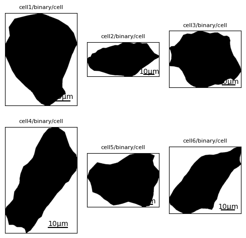

```python
# the segmentation was essentially done before in imageJ so the non-cell pixels are set to zero for all the images

threshold = 0

for cell in cell_list:
    cells_mask = sk.morphology.closing(dataset[cell]["raw"]["nucleus"] >threshold,sk.morphology.disk(5))
    dataset[cell]["binary"]["cell"] = cells_mask

multiplot(dataset,cell_list, ["binary"],["cell"])
```

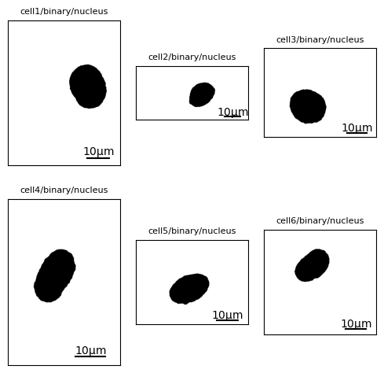

```python
threshold = 10

for cell in cell_list:
    nucleus_mask = dataset[cell]["raw"]["nucleus"] > threshold
    nucleus_mask = sk.morphology.remove_small_holes(nucleus_mask,20)
    nucleus_mask = sk.morphology.remove_small_objects(nucleus_mask,100)
    nucleus_mask = sk.morphology.closing(nucleus_mask, sk.morphology.disk(10))
    nucleus_mask = sk.morphology.opening(nucleus_mask, sk.morphology.disk(10))
    dataset[cell]["binary"]["nucleus"] = nucleus_mask

multiplot(dataset,cell_list, ["binary"],["nucleus"])
```

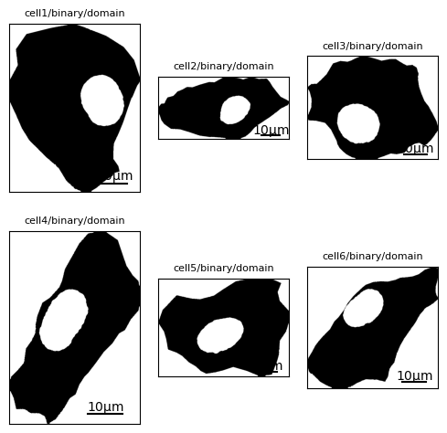

```python
for cell in cell_list:
    dataset[cell]["binary"]["domain"] = dataset[cell]["binary"]["cell"] & ~ dataset[cell]["binary"]["nucleus"]
multiplot(dataset,cell_list, ["binary"],["domain"])
```

Now we will identify the contours using `cv2.findContours`, and we make the contours are closed, by appending a copy of the the first coordinate set to the end of the contour coordinates

```python
for cell in cell_list:

    cell_contour, _ = cv2.findContours(dataset[cell]["binary"]["cell"].astype(np.uint8), cv2.RETR_EXTERNAL, cv2.CHAIN_APPROX_SIMPLE)
    dataset[cell]["contours"]["cell"] = cell_contour[0][:,0,:]/scale
    dataset[cell]["contours"]["cell"] = np.vstack((dataset[cell]["contours"]["cell"],dataset[cell]["contours"]["cell"][0]))

    nucleus_contour, _ = cv2.findContours(dataset[cell]["binary"]["nucleus"].astype(np.uint8), cv2.RETR_EXTERNAL, cv2.CHAIN_APPROX_SIMPLE)
    dataset[cell]["contours"]["nucleus"] = nucleus_contour[0][:,0,:]/scale
    dataset[cell]["contours"]["nucleus"] = np.vstack((dataset[cell]["contours"]["nucleus"],dataset[cell]["contours"]["nucleus"][0]))
```

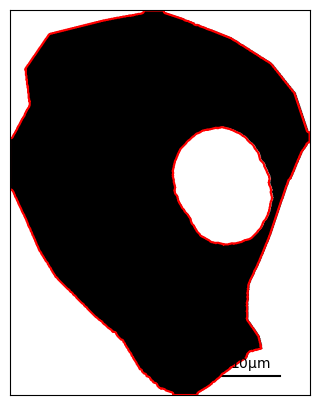

```python
fig, ax = plt.subplots(nrows=1, ncols=1, figsize=(5 ,5))
test_cell = "cell1"
imshow(ax,dataset[test_cell]["binary"]["domain"])
ax.plot(dataset[test_cell]["contours"]["cell"][:,0],dataset[test_cell]["contours"]["cell"][:,1],color = "red")
ax.plot(dataset[test_cell]["contours"]["nucleus"][:,0],dataset[test_cell]["contours"]["nucleus"][:,1],color = "red")
```

## Creating Binary Masks

We will generate **binary masks** for specific imaged components to isolate structures for quantitative analysis:

- **Mitochondria**
- **Endoplasmic Reticulum (ER)**
- **Golgi Apparatus**

Different threshold values will be applied manually, and results will be inspected to achieve optimal segmentation.

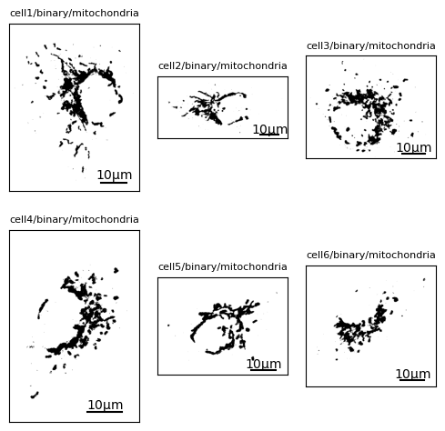

```python
mt_threshold = 80

for cell in cell_list:
    dataset[cell]["binary"]["mitochondria"] = dataset[cell]["raw"]["mitochondria"] > mt_threshold

multiplot(dataset,cell_list, ["binary"],["mitochondria"])
```

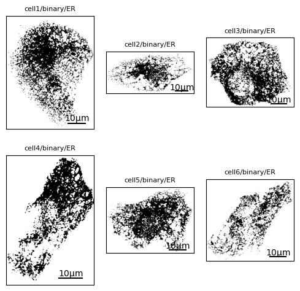

```python
er_threshold= 1600

for cell in cell_list:
    dataset[cell]["binary"]["ER"] = dataset[cell]["raw"]["ER"] > er_threshold

multiplot(dataset,cell_list, ["binary"],["ER"])
```

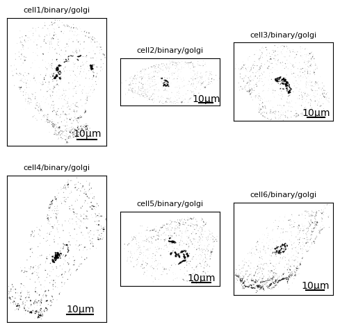

```python
golgi_threshold =  40

for cell in cell_list:
    dataset[cell]["binary"]["golgi"] = dataset[cell]["raw"]["golgi"] > golgi_threshold

multiplot(dataset,cell_list, ["binary"],["golgi"])
```

## Creating Proximity Maps

We will generate **proximity maps** to analyze spatial relationships between puncta and nearby structures:

- **Mitochondria**
- **Golgi Apparatus**

Let's proceed to generate the proximity maps and integrate them into our dataset.

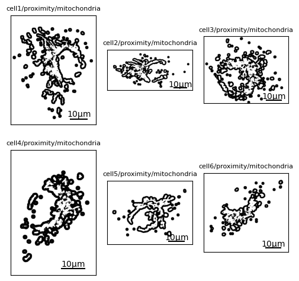

```python
def create_border_mask(binary_mask, distance):
    dilated_mask = sk.morphology.binary_dilation(binary_mask, footprint=sk.morphology.disk(distance))
    border_mask = dilated_mask & ~binary_mask
    return border_mask

for cell in cell_list:
    dataset[cell]["proximity"]["mitochondria"] = create_border_mask(dataset[cell]["binary"]["mitochondria"],scale)

multiplot(dataset,cell_list, ["proximity"],["mitochondria"])
```

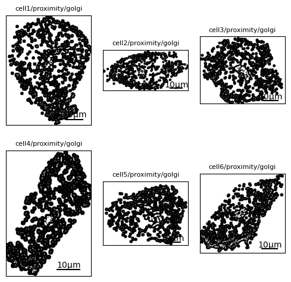

```python
for cell in cell_list:
    dataset[cell]["proximity"]["golgi"] = create_border_mask(dataset[cell]["binary"]["golgi"],scale)

multiplot(dataset,cell_list, ["proximity"],["golgi"])
```

## Creating Relative Distance Maps

We will generate **distance maps** for large cellular structures, specifically the **nucleus** and **cell border**, to capture heterogeneity in puncta distribution:

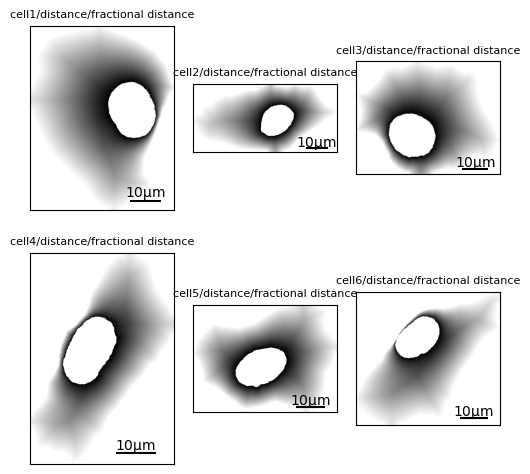

```python
for cell in cell_list:
    dataset[cell]["distance"]["nucleus"] = sp.ndimage.distance_transform_edt( ~dataset[cell]["binary"]["nucleus"])*dataset[cell]["binary"]["domain"]/scale
    dataset[cell]["distance"]["cell"] = sp.ndimage.distance_transform_edt( dataset[cell]["binary"]["cell"])*dataset[cell]["binary"]["domain"]/scale
    dataset[cell]["distance"]["fractional distance"] =  np.divide(dataset[cell]["distance"]["cell"],dataset[cell]["distance"]["nucleus"]+dataset[cell]["distance"]["cell"],out=np.zeros_like(dataset[cell]["distance"]["cell"]),
            where=dataset[cell]["distance"]["nucleus"]+dataset[cell]["distance"]["cell"]!=0)

multiplot(dataset,cell_list, ["distance"],["fractional distance"])
```

## Stitching Data Across Multiple Cells for Spatial Analysis

In our spatial analysis, we aim to investigate patterns not only within individual cells but also across multiple cells. To perform spatial analysis on multiple cells collectively, we need to **geographically stitch** the images, contours, and point patterns from individual cells into a single, cohesive dataset. This process involves aligning the data from multiple cells into a common coordinate system, effectively combining them into a larger spatial domain.

```python
def stitch(big_matrix,small_matrix,x0,y0):
    big_matrix[y0:y0+small_matrix.shape[0], x0:x0+small_matrix.shape[1]] = small_matrix
    return big_matrix

shift = dict()
shift["cell1"] = {"x": 150, "y" :150}
shift["cell2"] = {"x": 150, "y" :1150}
shift["cell3"] = {"x": 1200, "y" :1000}
shift["cell4"] = {"x": 1200, "y" :150}
shift["cell5"] = {"x": 2070, "y" :1000}
shift["cell6"] = {"x": 2000, "y" :150}

dataset["stitched"] = dict()

image_sets = ["raw","binary","proximity","distance"]

for image_set in image_sets:
    dataset["stitched"][image_set] = dict()
    for key, value in dataset["cell1"][image_set].items():
        bigger_picture = np.zeros((1700,2800),dtype = dataset[cell_list[0]][image_set][key].dtype)
        for cell in cell_list:
            bigger_picture = stitch(bigger_picture,dataset[cell][image_set][key],shift[cell]["x"],shift[cell]["y"])
        dataset["stitched"][image_set][key] = bigger_picture

dataset["stitched"]["contours"] = dict()

for cell in cell_list:
    dataset["stitched"]["contours"][cell] = dict()
    shifted_contour = dataset[cell]["contours"]["nucleus"].copy()
    shifted_contour[:,0] += shift[cell]["x"]/scale
    shifted_contour[:,1] += shift[cell]["y"]/scale
    dataset["stitched"]["contours"][cell]["nucleus"] = shifted_contour

    shifted_contour = dataset[cell]["contours"]["cell"].copy()
    shifted_contour[:,0] += shift[cell]["x"]/scale
    shifted_contour[:,1] += shift[cell]["y"]/scale
    dataset["stitched"]["contours"][cell]["cell"] = shifted_contour

dataset["stitched"]["point patterns"] = dict()
dataset["stitched"]["point patterns"]["peroxisomes"] = np.zeros((3,0))
dataset["stitched"]["point patterns"]["lipid droplets"] = np.zeros((3,0))

for cell in cell_list:
    shifted_point_pattern = dataset[cell]["point patterns"]["peroxisomes"].copy()
    shifted_point_pattern[0] += shift[cell]["x"]/scale
    shifted_point_pattern[1] += shift[cell]["y"]/scale
    dataset["stitched"]["point patterns"]["peroxisomes"] = np.hstack((dataset["stitched"]["point patterns"]["peroxisomes"],shifted_point_pattern))

    shifted_point_pattern = dataset[cell]["point patterns"]["lipid droplets"].copy()
    shifted_point_pattern[0] += shift[cell]["x"]/scale
    shifted_point_pattern[1] += shift[cell]["y"]/scale
    dataset["stitched"]["point patterns"]["lipid droplets"] = np.hstack((dataset["stitched"]["point patterns"]["lipid droplets"],shifted_point_pattern))
```

```python
def bounding_box(small_matrix,x0,y0,margin):
    width = small_matrix.shape[1]
    height = small_matrix.shape[0]
    left = x0 - margin
    right = x0 + width + margin
    bot = y0 - margin
    top = y0 + height + margin
    xs = [left,left,right,right,left]
    ys = [bot,top,top, bot,bot]
    return np.array([xs, ys])/scale

dataset["stitched"]["bounding boxes"] = dict()
for cell in cell_list:
    dataset["stitched"]["bounding boxes"][cell] =  bounding_box(dataset[cell]["raw"]["nucleus"],shift[cell]["x"],shift[cell]["y"],100)
```

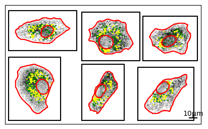

```python
fig, ax = plt.subplots(nrows=1, ncols=1, figsize=(5 ,5))
imshow(ax,dataset["stitched"]["raw"]["ER"])

ax.scatter(dataset["stitched"]["point patterns"]["peroxisomes"][0],dataset["stitched"]["point patterns"]["peroxisomes"][1], s = 1, color = "green")
ax.scatter(dataset["stitched"]["point patterns"]["lipid droplets"][0],dataset["stitched"]["point patterns"]["lipid droplets"][1], s = 1, color = "yellow")

for cell in cell_list:
    ax.plot(dataset["stitched"]["contours"][cell]["cell"][:,0],dataset["stitched"]["contours"][cell]["cell"][:,1],color = "red")
    ax.plot(dataset["stitched"]["contours"][cell]["nucleus"][:,0],dataset["stitched"]["contours"][cell]["nucleus"][:,1], color = "red")
    ax.plot(dataset["stitched"]["bounding boxes"][cell][0],dataset["stitched"]["bounding boxes"][cell][1],color = "black")
```

## Saving Processed Data for Further Analysis

With all preprocessing steps completed, we now need to save our data for future use. First, we will save the entire dataset as a Python-friendly object using **pickle**, which allows us to preserve the dataset's structure and quickly reload it in Python for any additional processing or analysis.

Next, we will export the different data objects into file formats compatible with the spatial analysis tools we plan to use later, such as **R**. By saving the data in formats that these tools can readily import, we streamline the workflow and ensure seamless integration between Python preprocessing and subsequent spatial modeling.

### Steps for Saving Data*

```python
import pickle

# Save the dictionary to a file
with open("../data/processed/pickled_dataset.pkl", 'wb') as file:
    pickle.dump(dataset, file)
```

```python
for cell in cell_list:
    peroxisomes_data = dataset[cell]["point patterns"]["peroxisomes"].copy()
    peroxisomes_dictionary = {
        'id': np.arange(peroxisomes_data.shape[1]).tolist(),
        'organelle': peroxisomes_data.shape[1]*["peroxisome"],
        'r': peroxisomes_data[2].tolist(),
        'x':  peroxisomes_data[0].tolist(),
        'y': peroxisomes_data[1].tolist()
    }
    gdf = gpd.GeoDataFrame(peroxisomes_dictionary, geometry=gpd.points_from_xy(peroxisomes_dictionary['x'], peroxisomes_dictionary['y']), crs=None)
    gdf.to_file("../data/processed/inlabru_compatible/"+cell+"/peroxisomes.geojson", driver="GeoJSON",crs=None)


for cell in cell_list:
    lipid_data = dataset[cell]["point patterns"]["lipid droplets"].copy()
    lipid_dictionary = {
        'id': np.arange(lipid_data.shape[1]).tolist(),
        'organelle': lipid_data.shape[1]*["lipid droplet"],
        'r': lipid_data[2].tolist(),
        'x':  lipid_data[0].tolist(),
        'y': lipid_data[1].tolist()
    }
    gdf = gpd.GeoDataFrame(lipid_dictionary, geometry=gpd.points_from_xy(lipid_dictionary['x'], lipid_dictionary['y']), crs=None)
    gdf.to_file("../data/processed/inlabru_compatible/"+cell+"/lipid_droplets.geojson", driver="GeoJSON",crs=None)
```

```python
peroxisomes_data = dataset["stitched"]["point patterns"]["peroxisomes"].copy()
peroxisomes_dictionary = {
        'id': np.arange(peroxisomes_data.shape[1]).tolist(),
        'organelle': peroxisomes_data.shape[1]*["peroxisome"],
        'r': peroxisomes_data[2].tolist(),
        'x':  peroxisomes_data[0].tolist(),
        'y': peroxisomes_data[1].tolist()
}
gdf = gpd.GeoDataFrame(peroxisomes_dictionary, geometry=gpd.points_from_xy(peroxisomes_dictionary['x'], peroxisomes_dictionary['y']), crs=None)
gdf.to_file("../data/processed/inlabru_compatible/stitched_cells1-6/peroxisomes.geojson", driver="GeoJSON",crs=None)

lipid_data = dataset["stitched"]["point patterns"]["lipid droplets"].copy()
lipid_dictionary = {
        'id': np.arange(lipid_data.shape[1]).tolist(),
        'organelle': lipid_data.shape[1]*["lipid_droplet"],
        'r': lipid_data[2].tolist(),
        'x':  lipid_data[0].tolist(),
        'y': lipid_data[1].tolist()
}
gdf = gpd.GeoDataFrame(lipid_dictionary, geometry=gpd.points_from_xy(lipid_dictionary['x'], lipid_dictionary['y']), crs=None)
gdf.to_file("../data/processed/inlabru_compatible/stitched_cells1-6/lipid_droplets.geojson", driver="GeoJSON",crs=None)
```

```python
for cell in cell_list:

    domain_polygons = []
    p1 = shapely.geometry.Polygon(zip(dataset[cell]["contours"]["nucleus"][:,0], dataset[cell]["contours"]["nucleus"][:,1]))
    p2 = shapely.geometry.Polygon(zip(dataset[cell]["contours"]["cell"][:,0], dataset[cell]["contours"]["cell"][:,1]))
    domain_polygons.append(shapely.geometry.Polygon(p2.exterior.coords, [p1.exterior.coords]))
    contour_dicitonary = {'ID': [cell], 'geometry': domain_polygons}
    gdf_polygons = gpd.GeoDataFrame(contour_dicitonary)
    gdf_polygons.to_file("../data/processed/inlabru_compatible/" + cell + "/domain.geojson", driver="GeoJSON",crs=None)


domain_polygons = []
for cell in cell_list:
    p1 = shapely.geometry.Polygon(zip(dataset["stitched"]["contours"][cell]["nucleus"][:,0], dataset["stitched"]["contours"][cell]["nucleus"][:,1]))
    p2 = shapely.geometry.Polygon(zip(dataset["stitched"]["contours"][cell]["cell"][:,0], dataset["stitched"]["contours"][cell]["cell"][:,1]))
    domain_polygons.append(shapely.geometry.Polygon(p2.exterior.coords, [p1.exterior.coords]))


contour_dicitonary = {'ID': np.arange(1,7).tolist(), 'geometry': domain_polygons}
gdf_polygons = gpd.GeoDataFrame(contour_dicitonary)  # Using WGS84 CRS as an example
gdf_polygons.to_file("../data/processed/inlabru_compatible/stitched_cells1-6/domain.geojson", driver="GeoJSON",crs=None)


box_polygons = [shapely.geometry.Polygon(zip(dataset["stitched"]["bounding boxes"][cell][0],dataset["stitched"]["bounding boxes"][cell][1])) for cell in cell_list ]
gdf = gpd.GeoDataFrame(geometry=box_polygons)
gdf.to_file("../data/processed/inlabru_compatible/stitched_cells1-6/meshbox.geojson", driver="GeoJSON",crs=None)
```

```python
def save_rast(matrix,scale,output_file):
    matrix_f = np.flipud(matrix)

    resolution = 1/scale  # Resolution in micrometers (assuming square cells)

    # Calculate the transform matrix
    transform = rasterio.transform.from_origin(0, matrix.shape[0]/scale, resolution, resolution)

    if (matrix_f.dtype).name == "bool":
        matrix_f = matrix_f.astype(np.uint8)

    # Create a rasterio MemoryFile object to write the raster data
    with rasterio.open(output_file, 'w', driver='GTiff', height=matrix_f.shape[0], width=matrix_f.shape[1],
                           count=1, dtype= (matrix_f.dtype).name, crs= None,
                           transform=transform) as dst:
            # Write the matrix data to the raster dataset
            dst.write(matrix_f, 1)

image_sets = ["raw","binary","proximity","distance"]

for cell in cell_list:
    for image_set in image_sets:
        for image_name, image in dataset[cell][image_set].items():
            save_rast(image,scale,"../data/processed/inlabru_compatible/"+ cell +"/" + image_set + "/" + image_name + ".tif")


for image_set in image_sets:
    for image_name, image in dataset["stitched"][image_set].items():
        save_rast(image,scale,"../data/processed/inlabru_compatible/stitched_cells1-6/" + image_set + "/" + image_name + ".tif")
```

## Next step in R

Now with all the processed data saved in a convinient format, we continue with the spatial analysis in `R`